# Projet Econométrie

Etude de la base de données portant sur le prix des logements

Léa BRASSEUR & Neil DUPIN

Dans un premier temps, nous voyons que la base de données porte sur les logements et leurs différentes caractéristiques. Le but de cette étude va être de déterminer quelles variables influencent le prix des logements.

# La base de données

### *Statistiques descriptives*

```
##        id                date               price            bedrooms
##  Min.   :1.000e+06   Length:21613       Min.   :  75000   Min.   : 0.000
##  1st Qu.:2.123e+09   Class :character   1st Qu.: 321950   1st Qu.: 3.000
##  Median :3.905e+09   Mode  :character   Median : 450000   Median : 3.000
##  Mean   :4.580e+09                      Mean   : 540088   Mean   : 3.371
##  3rd Qu.:7.309e+09                      3rd Qu.: 645000   3rd Qu.: 4.000
##  Max.   :9.900e+09                      Max.   :7700000   Max.   :33.000
##    bathrooms      sqft_living       sqft_lot           floors
##  Min.   :0.000   Min.   :  290   Min.   :    520   Min.   :1.000
##  1st Qu.:1.750   1st Qu.: 1427   1st Qu.:   5040   1st Qu.:1.000
##  Median :2.250   Median : 1910   Median :   7618   Median :1.500
##  Mean   :2.115   Mean   : 2080   Mean   :  15107   Mean   :1.494
##  3rd Qu.:2.500   3rd Qu.: 2550   3rd Qu.:  10688   3rd Qu.:2.000
##  Max.   :8.000   Max.   :13540   Max.   :1651359   Max.   :3.500
##    waterfront            view          condition         grade
##  Min.   :0.000000   Min.   :0.0000   Min.   :1.000   Min.   : 1.000
##  1st Qu.:0.000000   1st Qu.:0.0000   1st Qu.:3.000   1st Qu.: 7.000
##  Median :0.000000   Median :0.0000   Median :3.000   Median : 7.000
##  Mean   :0.007542   Mean   :0.2343   Mean   :3.409   Mean   : 7.657
##  3rd Qu.:0.000000   3rd Qu.:0.0000   3rd Qu.:4.000   3rd Qu.: 8.000
##  Max.   :1.000000   Max.   :4.0000   Max.   :5.000   Max.   :13.000
##    sqft_above   sqft_basement       yr_built     yr_renovated
##  Min.   : 290   Min.   :   0.0   Min.   :1900   Min.   :   0.0
##  1st Qu.:1190   1st Qu.:   0.0   1st Qu.:1951   1st Qu.:   0.0
##  Median :1560   Median :   0.0   Median :1975   Median :   0.0
##  Mean   :1788   Mean   : 291.5   Mean   :1971   Mean   :  84.4
##  3rd Qu.:2210   3rd Qu.: 560.0   3rd Qu.:1997   3rd Qu.:   0.0
##  Max.   :9410   Max.   :4820.0   Max.   :2015   Max.   :2015.0
##     zipcode           lat             long        sqft_living15
##  Min.   :98001   Min.   :47.16   Min.   :-122.5   Min.   : 399
##  1st Qu.:98033   1st Qu.:47.47   1st Qu.:-122.3   1st Qu.:1490
##  Median :98065   Median :47.57   Median :-122.2   Median :1840
##  Mean   :98078   Mean   :47.56   Mean   :-122.2   Mean   :1987
##  3rd Qu.:98118   3rd Qu.:47.68   3rd Qu.:-122.1   3rd Qu.:2360
##  Max.   :98199   Max.   :47.78   Max.   :-121.3   Max.   :6210
##    sqft_lot15
##  Min.   :   651
##  1st Qu.:  5100
##  Median :  7620
##  Mean   : 12768
##  3rd Qu.: 10083
##  Max.   :871200
```

```
## data
##
##  21  Variables      21613  Observations
## --------------------------------------------------------------------------------
## id
##         n   missing  distinct      Info      Mean       Gmd       .05       .10
##     21613         0     21436         1  4.58e+09 3.296e+09 5.125e+08 1.036e+09
##       .25       .50       .75       .90       .95
## 2.123e+09 3.905e+09 7.309e+09 8.732e+09 9.297e+09
##
## lowest :    1000102    1200019    1200021    2800031    3600057
## highest: 9842300095 9842300485 9842300540 9895000040 9900000190
## --------------------------------------------------------------------------------
## date
##        n  missing distinct
##    21613        0      372
##
## lowest : 20140502T000000 20140503T000000 20140504T000000 20140505T000000 20140506T000000
## highest: 20150513T000000 20150514T000000 20150515T000000 20150524T000000 20150527T000000
## --------------------------------------------------------------------------------
## price
##        n  missing distinct     Info     Mean      Gmd      .05      .10
##    21613        0     4028        1   540088   329387   210000   245000
##      .25      .50      .75      .90      .95
##   321950   450000   645000   887000  1156480
##
## lowest :   75000   78000   80000   81000   82000
## highest: 5350000 5570000 6885000 7062500 7700000
## --------------------------------------------------------------------------------
## bedrooms
##        n  missing distinct     Info     Mean      Gmd      .05      .10
##    21613        0       13    0.871    3.371    0.946        2        2
##      .25      .50      .75      .90      .95
##        3        3        4        4        5
##
## lowest :  0  1  2  3  4, highest:  8  9 10 11 33
##
## Value          0     1     2     3     4     5     6     7     8     9    10
## Frequency     13   199  2760  9824  6882  1601   272    38    13     6     3
## Proportion 0.001 0.009 0.128 0.455 0.318 0.074 0.013 0.002 0.001 0.000 0.000
```

[output cut: 150 more lines]

```
##        n  missing distinct     Info     Mean      Gmd      .05      .10
##    21613        0      777        1     1987    743.2     1140     1256
##      .25      .50      .75      .90      .95
##     1490     1840     2360     2930     3300
##
## lowest :  399  460  620  670  690, highest: 5600 5610 5790 6110 6210
## --------------------------------------------------------------------------------
## sqft_lot15
##        n  missing distinct     Info     Mean      Gmd      .05      .10
##    21613        0     8689        1    12768    13404     1999     3667
##      .25      .50      .75      .90      .95
##     5100     7620    10083    17852    37063
##
## lowest :    651    659    660    748    750, highest: 434728 438213 560617 858132 871200
## --------------------------------------------------------------------------------
```

### *Première visualisation des variables*

Nous partons du principe qu’il n’est pas nécessaire de conserver les variables id et date puisqu’elles n’ont pas de lien avec le prix.

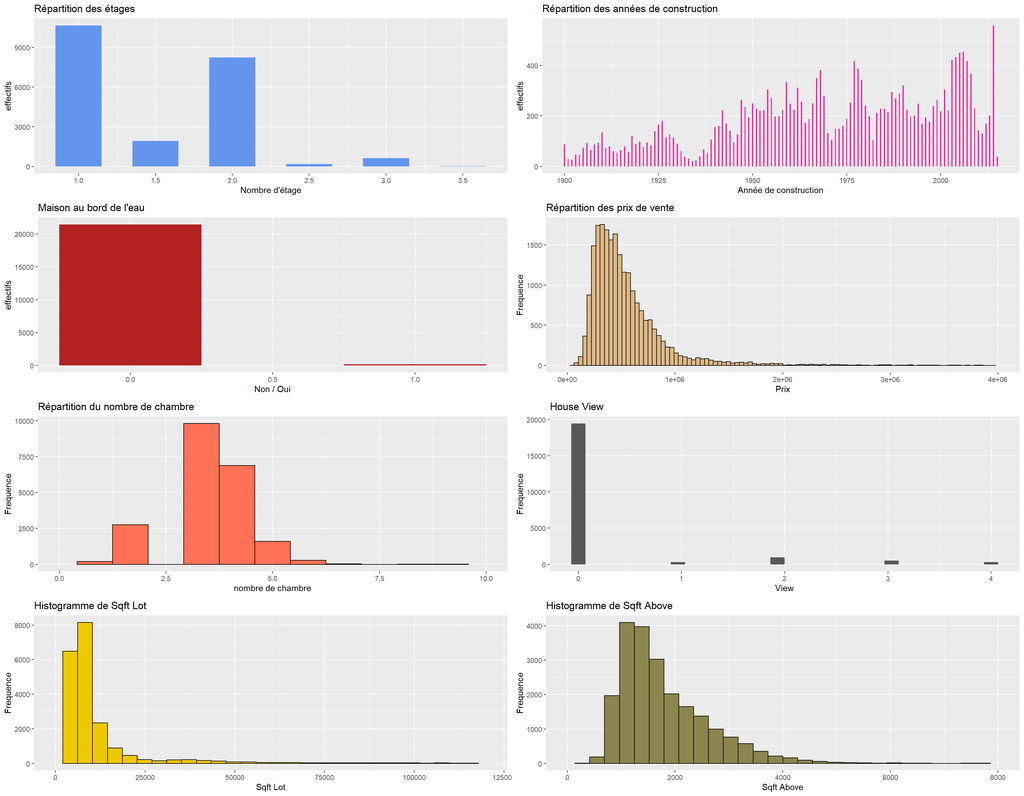

- La répartition des étages n’est pas vraiment homogène, la plupart des maisons ont 1 ou 2 étages.
- La majorité des maisons ont été construites après les années 1950.
- Très peu de maison sont au bord de l’eau.
- La plupart de maisons possèdent 3 ou 4 chambres.
- Pour la majorité des logements, la variable view est égale à 0.
- La variable sqft_above suit la même tendance que sqft_lot.

### *Corrélation*

```r
as.dist(round(cor(data),2))
```

```
##               price bedrooms bathrooms sqft_living sqft_lot floors waterfront
## bedrooms       0.31
## bathrooms      0.53     0.52
## sqft_living    0.70     0.58      0.75
## sqft_lot       0.09     0.03      0.09        0.17
## floors         0.26     0.18      0.50        0.35    -0.01
## waterfront     0.27    -0.01      0.06        0.10     0.02   0.02
## view           0.40     0.08      0.19        0.28     0.07   0.03       0.40
## condition      0.04     0.03     -0.12       -0.06    -0.01  -0.26       0.02
## grade          0.67     0.36      0.66        0.76     0.11   0.46       0.08
## sqft_above     0.61     0.48      0.69        0.88     0.18   0.52       0.07
## sqft_basement  0.32     0.30      0.28        0.44     0.02  -0.25       0.08
## yr_built       0.05     0.15      0.51        0.32     0.05   0.49      -0.03
## yr_renovated   0.13     0.02      0.05        0.06     0.01   0.01       0.09
## zipcode       -0.05    -0.15     -0.20       -0.20    -0.13  -0.06       0.03
## lat            0.31    -0.01      0.02        0.05    -0.09   0.05      -0.01
## long           0.02     0.13      0.22        0.24     0.23   0.13      -0.04
## sqft_living15  0.59     0.39      0.57        0.76     0.14   0.28       0.09
## sqft_lot15     0.08     0.03      0.09        0.18     0.72  -0.01       0.03
##                view condition grade sqft_above sqft_basement yr_built
## bedrooms
## bathrooms
## sqft_living
## sqft_lot
## floors
## waterfront
## view
## condition      0.05
## grade          0.25     -0.14
## sqft_above     0.17     -0.16  0.76
## sqft_basement  0.28      0.17  0.17      -0.05
## yr_built      -0.05     -0.36  0.45       0.42         -0.13
## yr_renovated   0.10     -0.06  0.01       0.02          0.07    -0.22
## zipcode        0.08      0.00 -0.18      -0.26          0.07    -0.35
## lat            0.01     -0.01  0.11       0.00          0.11    -0.15
## long          -0.08     -0.11  0.20       0.34         -0.14     0.41
## sqft_living15  0.28     -0.09  0.71       0.73          0.20     0.33
## sqft_lot15     0.07      0.00  0.12       0.19          0.02     0.07
##               yr_renovated zipcode   lat  long sqft_living15
## bedrooms
## bathrooms
## sqft_living
## sqft_lot
## floors
## waterfront
## view
## condition
## grade
## sqft_above
## sqft_basement
## yr_built
## yr_renovated
## zipcode               0.06
## lat                   0.03    0.27
## long                 -0.07   -0.56 -0.14
## sqft_living15         0.00   -0.28  0.05  0.33
## sqft_lot15            0.01   -0.15 -0.09  0.25          0.18
```

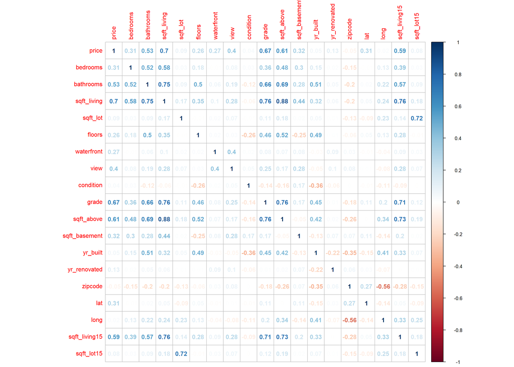

```r
num_plot<- corrplot(cor(data),method= "number")
```

Nous pouvons voir grâce à cette matrice que la variable sqft_living est fortement corrélée avec les variables price, grade et sqft_above.

### *Relation avec le prix*

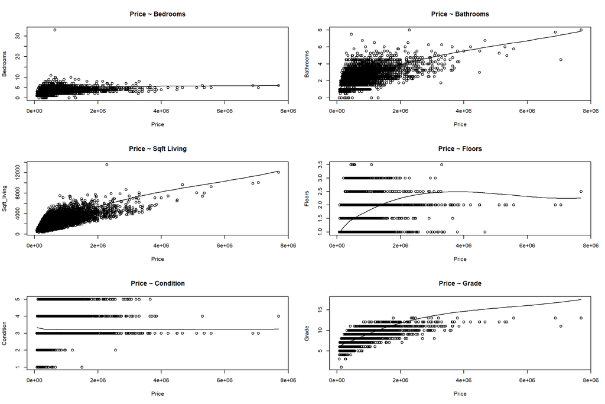

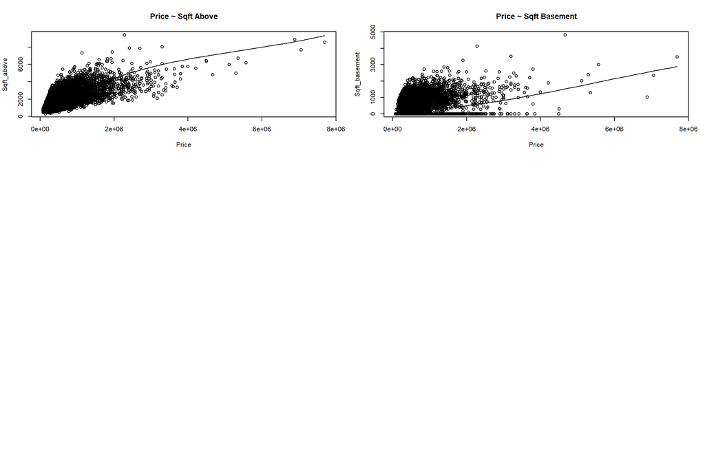

Nous supprimons les variables qui n’ont pas de lien avec le prix d’après la matrice de corrélation et les graphiques précédents et celles qui ne nous semblent pas pertinentes.

```r
data2 <- data[,c(-5,-6,-7,-8,-9,-12,-13,-14,-15,-16,-17,-18,-19)]
```

Il ne nous reste plus que les variables price, bedrooms, bathrooms, sqft_living, grade et sqft_above.

### *Valeurs aberrantes*

Puis, nous faisons quelques tests pour trouver les valeurs qui peuvent nous sembler aberrantes.

```r
table(data2$bedrooms)
```

```
##
##    0    1    2    3    4    5    6    7    8    9   10   11   33
##   13  199 2760 9824 6882 1601  272   38   13    6    3    1    1
```

```r
sup <- which(data2$bedrooms==11 | data2$bedrooms==33)
```

```r
databis <- data2[-sup,]
```

# Régression linéaire 1

Nous faisons notre première régression avec les variables les plus corrélées au prix.

```r
databis_lm <- lm(formula = price ~ bedrooms + bathrooms + sqft_living + grade + sqft_above, data = databis)
```

# Analyse de la régression 1

```r
summary(databis_lm)
```

```
##
## Call:
## lm(formula = price ~ bedrooms + bathrooms + sqft_living + grade +
##     sqft_above, data = databis)
##
## Residuals:
##      Min       1Q   Median       3Q      Max
## -1076874  -131872   -23044    95056  4589694
##
## Coefficients:
##               Estimate Std. Error t value Pr(>|t|)
## (Intercept) -5.167e+05  1.515e+04 -34.101  < 2e-16 ***
## bedrooms    -4.472e+04  2.370e+03 -18.872  < 2e-16 ***
## bathrooms   -2.411e+04  3.457e+03  -6.974 3.16e-12 ***
## sqft_living  2.807e+02  4.566e+00  61.483  < 2e-16 ***
## grade        1.067e+05  2.382e+03  44.780  < 2e-16 ***
## sqft_above  -7.950e+01  4.379e+00 -18.155  < 2e-16 ***
## ---
## Signif. codes:  0 '***' 0.001 '**' 0.01 '*' 0.05 '.' 0.1 ' ' 1
##
## Residual standard error: 246100 on 21605 degrees of freedom
## Multiple R-squared:  0.551,  Adjusted R-squared:  0.5509
## F-statistic:  5302 on 5 and 21605 DF,  p-value: < 2.2e-16
```

### *R²*

Nous observons un **R² = 0.551**, ce qui veut dire que le modèle explique 55.1% de la variabilité des prix des maisons. Ce modèle a une qualité d’ajustement moyenne puisque le R² se trouve toujours entre 0 et 1. Pour le R² ajusté, il est presque égal au R².

### *Significativé globale du modèle*

**p-value < 2.2e-16 < alpha = 0.01**

Ce qui veut dire que nous rejettons l’hypothèse nulle et donc le modèle est globalement significatif.

### *Les résidus*

Pour accepter les résultats d’une régression, il faut que les résidus soient identiquement distribués et de manière aléatoire. Ils doivent également être homoscédastiques, être indépendants et suivre une loi normale.

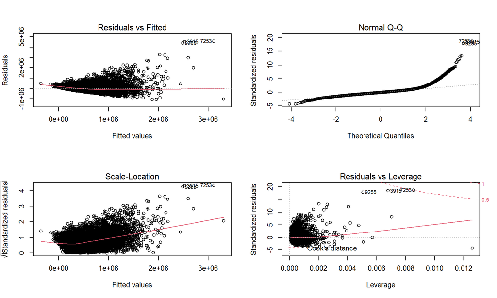

```r
par(mfrow=c(2,2))
plot(databis_lm)
```

- *Normalité*

```r
pearson.test(databis_lm$residuals)
```

```
##
##  Pearson chi-square normality test
##
## data:  databis_lm$residuals
## P = 3780.1, p-value < 2.2e-16
```

**p-value < 2.2e-16 < alpha = 0.01**

Nous rejettons H0, l’hypothèse de normalité des résidus.

D’après le test de Pearson, nous pouvons conclure que les résidus ne suivent pas une loi normale. De plus, nous pouvons également le remarquer sur le graphique “Normal Q-Q” car les points ne se trouvent pas tous sur la droite.

- *Homoscédasticité*

```r
bptest(databis_lm)
```

```
##
##  studentized Breusch-Pagan test
##
## data:  databis_lm
## BP = 2366.7, df = 5, p-value < 2.2e-16
```

**p-value < 2.2e-16 < alpha = 0.01**

D’après le test, on rejette H0. Ce qui veut dire que les variances ne sont pas constantes, elles sont hétéroscédastiques.

De plus, nous voyons, grâce au graphique “Scale-Location” que la droite de tendance n’est pas horizontale ce qui nous montre bien qu’il y a une tendance particulière au niveau de la distribution des résidus.

- *Linéarité*

D’après le graphique “Residuals vs Fitted”, nous pouvons voir que les résidus ont tendance, pour la plupart, à se regrouper et donc qu’ils ne sont pas distribués aléatoirement. L’hypothèse de linéarité est donc rejettée.

- *Valeurs aberrantes*

Nous pouvons voir sur le graphique “Residuals vs Leverage” que certaines valeurs se distinguent et ne font pas parties du nuage de points. Ces valeurs peuvent être qualifiées de valeurs aberrantes.

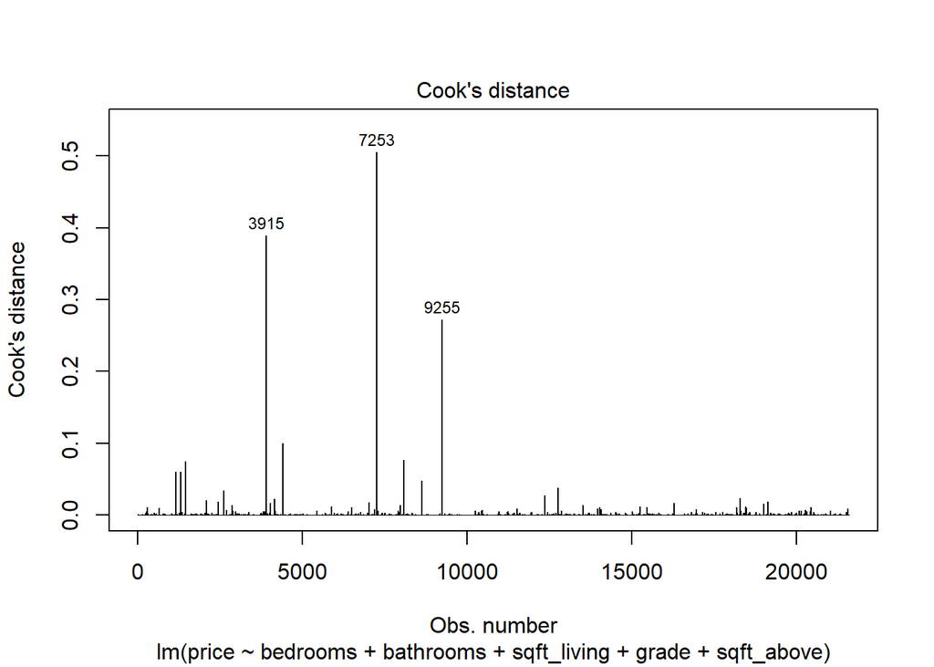

```r
plot(databis_lm, 4)
```

Nous pouvons voir que la distance de Cook ne dépasse jamais 1. Cependant, nous distiguons 3 valeurs qui ont une tendance différente de celles des autres.

### *Conclusion*

Les résultats ne peuvent pas être acceptés puisque les résidus ne suivent pas une loi normale, ils ne sont pas homoscédastiques et ils ne sont pas distribués aléatoirement.

```r
model_performance(databis_lm)
```

|  | AIC | BIC | R2 | R2_adjusted | RMSE | Sigma |
| --- | --- | --- | --- | --- | --- | --- |
| 1 | 597865 | 597920.8 | 0.5509629 | 0.550859 | 246018 | 246052.2 |

De plus, nous pouvons voir que le AIC, le BIC ainsi que le RMSE (erreur quadratique moyenne) sont très élevés ce qui signifie que le modèle est mal ajusté.

# Régression linéaire 2

### *Les effets d’interractions*

Nous regardons les effets d’interractions pour savoir si toutes les variables sont nécessaires pour notre modèle suivant.

```r
interact <- lm(formula = price ~ yr_built + yr_renovated + yr_built*yr_renovated, data = data)
```

```r
stargazer(interact, use = "complete.obs", type = "text", keep.stat = c("n"))
```

```
##
## =================================================
##                           Dependent variable:
##                       ---------------------------
##                                  price
## -------------------------------------------------
## yr_built                     1,066.195***
##                                (87.408)
##
## yr_renovated                   -568.044
##                                (522.609)
##
## yr_built:yr_renovated            0.361
##                                 (0.269)
##
## Constant                   -1,572,620.000***
##                              (172,421.100)
##
## -------------------------------------------------
## Observations                    21,613
## =================================================
## Note:                 *p<0.1; **p<0.05; ***p<0.01
##
## ============
## complete.obs
## ------------
```

Nous pouvons voir qu’il y a un léger effet d’interraction entre ces 2 variables puisque le coefficients yr_built:yr_renovated est égal à **0.361**. Mais ce n’est pas assez pour pouvoir retirer l’une des variables de la régression.

```r
interact2 <- lm(formula = price ~ sqft_lot + sqft_lot15 + sqft_lot*sqft_lot15, data = data)
```

```r
stargazer(interact2, use = "complete.obs", type = "text", keep.stat = c("n"))
```

```
##
## ===============================================
##                         Dependent variable:
##                     ---------------------------
##                                price
## -----------------------------------------------
## sqft_lot                     0.785***
##                               (0.094)
##
## sqft_lot15                   0.862***
##                               (0.144)
##
## sqft_lot:sqft_lot15         -0.00000***
##                              (0.00000)
##
## Constant                  519,306.800***
##                             (2,919.389)
##
## -----------------------------------------------
## Observations                  21,613
## ===============================================
## Note:               *p<0.1; **p<0.05; ***p<0.01
##
## ============
## complete.obs
## ------------
```

### *Régression 2*

```r
data_lm <- lm(formula = price ~ bedrooms + bathrooms + sqft_living + sqft_lot + floors + condition + grade + sqft_basement + yr_built + yr_renovated + zipcode + lat + long + sqft_living15 + sqft_lot15, data = data)
```

```r
summary(data_lm)
```

```
##
## Call:
## lm(formula = price ~ bedrooms + bathrooms + sqft_living + sqft_lot +
##     floors + condition + grade + sqft_basement + yr_built + yr_renovated +
##     zipcode + lat + long + sqft_living15 + sqft_lot15, data = data)
##
## Residuals:
##      Min       1Q   Median       3Q      Max
## -1120757  -107522   -12627    78945  4371145
##
## Coefficients:
##                 Estimate Std. Error t value Pr(>|t|)
## (Intercept)   -5.503e+06  3.093e+06  -1.779  0.07523 .
## bedrooms      -4.608e+04  1.997e+03 -23.076  < 2e-16 ***
## bathrooms      4.304e+04  3.454e+03  12.462  < 2e-16 ***
## sqft_living    1.873e+02  3.890e+00  48.144  < 2e-16 ***
## sqft_lot       1.582e-01  5.085e-02   3.112  0.00186 **
## floors         1.103e+04  3.816e+03   2.890  0.00386 **
## condition      2.923e+04  2.496e+03  11.713  < 2e-16 ***
## grade          1.011e+05  2.277e+03  44.393  < 2e-16 ***
## sqft_basement -7.936e+00  4.564e+00  -1.739  0.08209 .
## yr_built      -2.832e+03  7.687e+01 -36.837  < 2e-16 ***
## yr_renovated   3.490e+01  3.869e+00   9.022  < 2e-16 ***
## zipcode       -4.783e+02  3.487e+01 -13.718  < 2e-16 ***
## lat            5.559e+05  1.134e+04  49.036  < 2e-16 ***
## long          -2.520e+05  1.392e+04 -18.105  < 2e-16 ***
## sqft_living15  4.029e+01  3.613e+00  11.153  < 2e-16 ***
## sqft_lot15    -3.270e-01  7.777e-02  -4.204 2.63e-05 ***
## ---
## Signif. codes:  0 '***' 0.001 '**' 0.01 '*' 0.05 '.' 0.1 ' ' 1
##
## Residual standard error: 213600 on 21597 degrees of freedom
## Multiple R-squared:  0.6616, Adjusted R-squared:  0.6613
## F-statistic:  2815 on 15 and 21597 DF,  p-value: < 2.2e-16
```

# Analyse de la régression 2

### *R²*

Ce modèle a un **R² = 0.6616** ce qui veut dire que le modèle explique 66.16% de la variabilité des prix des maisons.

### *Significativé globale du modèle*

**p-value < 2.2e-16 < alpha = 0.01**

Grâce au test de Fisher, nous pouvons dire que le modèle est globalement significatif.

### *Les résidus*

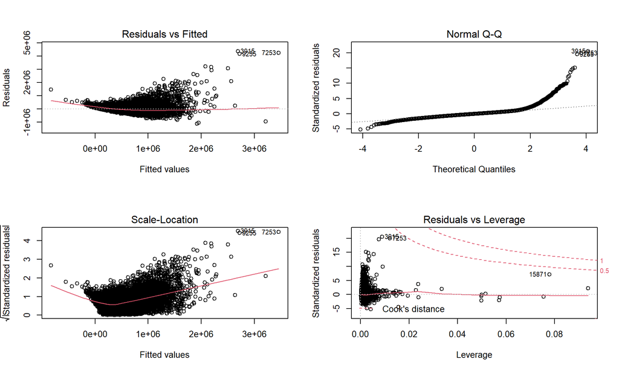

```r
par(mfrow=c(2,2))
plot(data_lm)
```

- *Normalité*

```r
pearson.test(data_lm$residuals)
```

```
##
##  Pearson chi-square normality test
##
## data:  data_lm$residuals
## P = 4551.5, p-value < 2.2e-16
```

**p-value < 2.2e-16 < alpha = 0.01**

D’après le graphique “Normal Q-Q” et le test de Pearson, nous pouvons conclure que les résidus ne suivent pas une loi normale.

- *Homoscédasticité*

```r
bptest(data_lm)
```

```
##
##  studentized Breusch-Pagan test
##
## data:  data_lm
## BP = 2559.2, df = 15, p-value < 2.2e-16
```

**p-value < 2.2e-16 < alpha = 0.01**

Nous voyons avec le test et le graphique que l’hypothèse nulle d’homoscédasticité est rejettée.

- *Linéarité*

Sur le graphique “Residuals vs Fitted” les résidus sont regroupés, ils ne sont pas distribués aléatoirement.

- *Valeurs aberrantes*

Tout comme dans le modèle précédent il est visible que certaines valeurs se distinguent des autres.

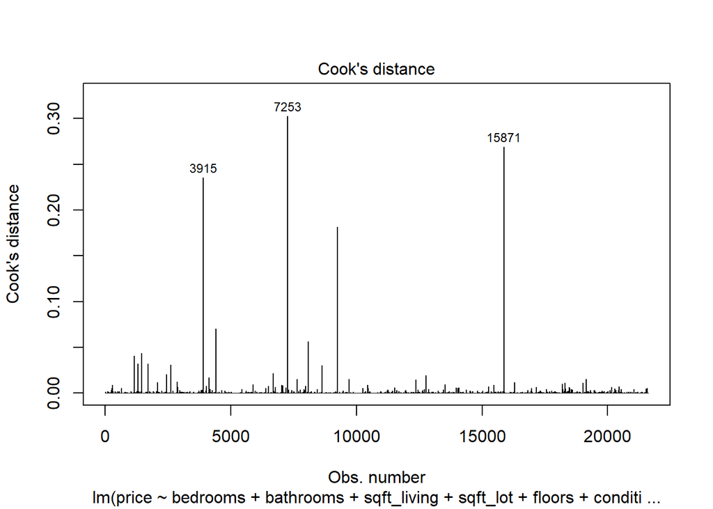

```r
plot(data_lm, 4)
```

Nous pouvons voir que la distance de Cook ne dépasse jamais 1. Cependant, nous distiguons 4 valeurs qui ont une tendance différente de celles des autres.

### *Conclusion*

Les résultats de la régression ne peuvent pas être acceptés car les résidus ne sont pas conformes.

```r
model_performance(data_lm)
```

|  | AIC | BIC | R2 | R2_adjusted | RMSE | Sigma |
| --- | --- | --- | --- | --- | --- | --- |
| 1 | 591826 | 591961.7 | 0.6615771 | 0.6613421 | 213568.1 | 213647.2 |

Nous voyons que le AIC, le BIC et le RMSE sont encore très élevés, mais moins que pour le modèle précédent. De plus, le R² a augmenté.

# Spécification du modèle

Nous décidons de faire une troisième régression dans le but d’avoir des résultats plus cohérents et un meilleur R². Pour cela, nous mettons la variable price au logarithme. Nous passons donc d’un modèle niveau-niveau à un modèle log-niveau.

```r
lm = lm(log(price) ~ bedrooms + bathrooms + sqft_living + sqft_lot + floors + condition + grade + sqft_basement + yr_built + yr_renovated + zipcode + lat + long + sqft_living15 + sqft_lot15   , data = data)
```

```r
summary(lm)
```

```
##
## Call:
## lm(formula = log(price) ~ bedrooms + bathrooms + sqft_living +
##     sqft_lot + floors + condition + grade + sqft_basement + yr_built +
##     yr_renovated + zipcode + lat + long + sqft_living15 + sqft_lot15,
##     data = data)
##
## Residuals:
##      Min       1Q   Median       3Q      Max
## -1.76418 -0.16592 -0.00024  0.16060  1.18960
##
## Coefficients:
##                 Estimate Std. Error t value Pr(>|t|)
## (Intercept)   -1.720e+01  3.760e+00  -4.575 4.78e-06 ***
## bedrooms      -2.127e-02  2.427e-03  -8.765  < 2e-16 ***
## bathrooms      7.114e-02  4.198e-03  16.947  < 2e-16 ***
## sqft_living    1.399e-04  4.728e-06  29.595  < 2e-16 ***
## sqft_lot       5.092e-07  6.181e-08   8.239  < 2e-16 ***
## floors         7.923e-02  4.639e-03  17.081  < 2e-16 ***
## condition      6.513e-02  3.034e-03  21.469  < 2e-16 ***
## grade          1.646e-01  2.768e-03  59.453  < 2e-16 ***
## sqft_basement  3.961e-05  5.548e-06   7.139 9.71e-13 ***
## yr_built      -3.626e-03  9.344e-05 -38.807  < 2e-16 ***
## yr_renovated   4.897e-05  4.703e-06  10.413  < 2e-16 ***
## zipcode       -5.388e-04  4.238e-05 -12.712  < 2e-16 ***
## lat            1.355e+00  1.378e-02  98.362  < 2e-16 ***
## long          -1.927e-01  1.692e-02 -11.386  < 2e-16 ***
## sqft_living15  1.178e-04  4.391e-06  26.819  < 2e-16 ***
## sqft_lot15    -2.164e-07  9.454e-08  -2.289   0.0221 *
## ---
## Signif. codes:  0 '***' 0.001 '**' 0.01 '*' 0.05 '.' 0.1 ' ' 1
##
## Residual standard error: 0.2597 on 21597 degrees of freedom
## Multiple R-squared:  0.757,  Adjusted R-squared:  0.7569
## F-statistic:  4486 on 15 and 21597 DF,  p-value: < 2.2e-16
```

# Analyse de la régression 3

### *R²*

La qualité d’ajustement de ce modèle vaut **0.757**, ce qui est assez proche de 1.

### *Significativé globale du modèle*

**p-value < 2.2e-16 < alpha = 0.01**

Le modèle est globalement significatif.

### *Les résidus*

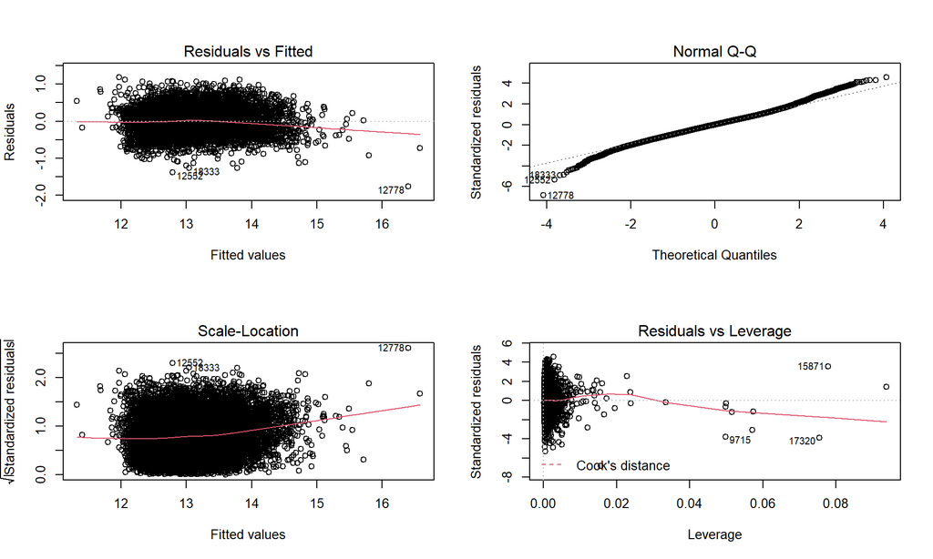

```r
par(mfrow=c(2,2))
plot(lm)
```

- *Normalité*

```r
pearson.test(lm$residuals)
```

```
##
##  Pearson chi-square normality test
##
## data:  lm$residuals
## P = 378.91, p-value < 2.2e-16
```

**p-value < 2.2e-16 < alpha = 0.01**

Le test et le graphique ne permettent pas d’accepter l’hypothèse de normalité des résidus.

- *Homoscédasticité*

```r
bptest(lm)
```

```
##
##  studentized Breusch-Pagan test
##
## data:  lm
## BP = 990.65, df = 15, p-value < 2.2e-16
```

**p-value < 2.2e-16 < alpha = 0.01**

Les résidus ne sont toujours pas homoscédastiques.

- *Linéarité*

Sur le graphique “Residuals vs Fitted”, les résidus sont plus éparpillés que pour les modèles précédents, il y a donc une distribution plus aléatoire.

- *Valeurs aberrantes*

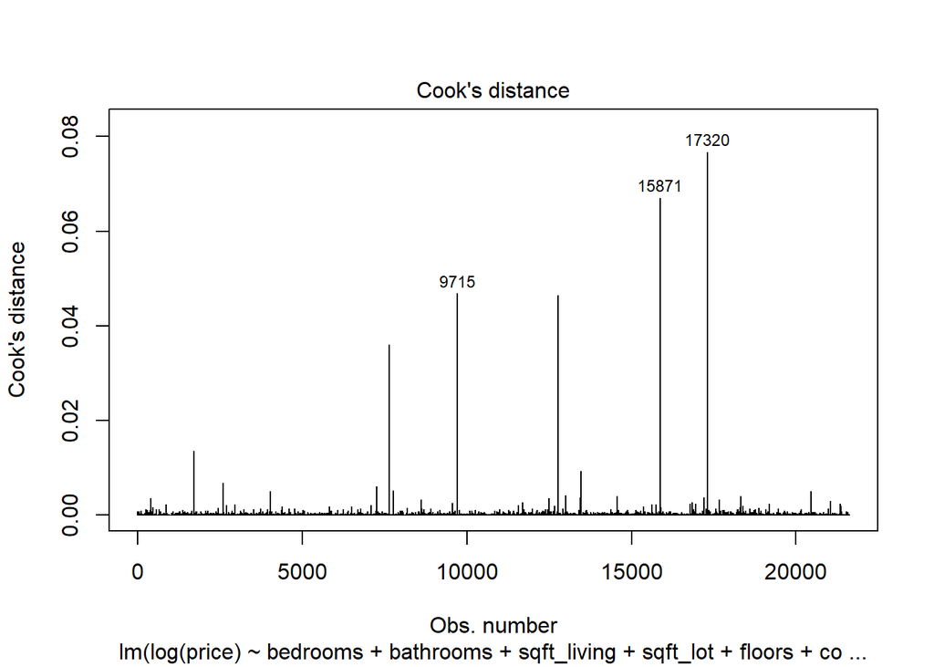

```r
plot(lm,4)
```

Nous avons 5 valeurs qui peuvent sembler aberrantes.

### *Conclusion*

```r
model_performance(lm)
```

|  | AIC | BIC | R2 | R2_adjusted | RMSE | Sigma |
| --- | --- | --- | --- | --- | --- | --- |
| 1 | 3074.694 | 3210.371 | 0.7570344 | 0.7568657 | 0.2596049 | 0.259701 |

Les valeurs du AIC, BIC et RMSE sont bien plus faible que pour les modèles précédents, ce qui veut dire que l’ajustement est meilleur.

# Spécification du modèle 2

Nous avons essayer de modifier la base de données en enlevant les valeurs aberrantes.

```r
newdata1 <- data2[-boxplot.stats(data2$price)$out, ]
newdata2 <- newdata1[-boxplot.stats(newdata1$bedrooms)$out, ]
newdata3 <- newdata2[-boxplot.stats(newdata2$bathrooms)$out, ]
newdata4 <- newdata3[-boxplot.stats(newdata3$sqft_living)$out, ]
newdata5 <- newdata4[-boxplot.stats(newdata4$grade)$out, ]
newdata6 <- newdata5[-boxplot.stats(newdata5$sqft_above)$out, ]
```

Nous nous retrouvons avec une nouvelle base de données composée de 6 variables et d’environ 21164 valeurs (500 de moins qu’au début).

### *Régression 4*

Cette régression est faite avec la nouvelle base de données. De plus, nous choisissons de mettre le prix en logartihme.

```r
lm2 <- lm(formula = log(price) ~ bedrooms + bathrooms + sqft_living + grade + sqft_above, data = newdata6)
```

```r
summary(lm2)
```

```
##
## Call:
## lm(formula = log(price) ~ bedrooms + bathrooms + sqft_living +
##     grade + sqft_above, data = newdata6)
##
## Residuals:
##      Min       1Q   Median       3Q      Max
## -1.84761 -0.24524  0.00304  0.23015  1.41489
##
## Coefficients:
##               Estimate Std. Error t value Pr(>|t|)
## (Intercept)  1.114e+01  2.137e-02 521.218  < 2e-16 ***
## bedrooms    -2.070e-02  3.239e-03  -6.390 1.69e-10 ***
## bathrooms   -1.059e-02  4.921e-03  -2.153   0.0313 *
## sqft_living  3.226e-04  6.471e-06  49.850  < 2e-16 ***
## grade        2.045e-01  3.386e-03  60.394  < 2e-16 ***
## sqft_above  -1.323e-04  6.234e-06 -21.223  < 2e-16 ***
## ---
## Signif. codes:  0 '***' 0.001 '**' 0.01 '*' 0.05 '.' 0.1 ' ' 1
##
## Residual standard error: 0.3468 on 21158 degrees of freedom
## Multiple R-squared:  0.5671, Adjusted R-squared:  0.567
## F-statistic:  5544 on 5 and 21158 DF,  p-value: < 2.2e-16
```

# Analyse de la régression 4

### *Coefficients, R² et significativité*

Le R² est de **0.5671**. Il est un peu plus élevé que pour le modèle 1 (qui comportait les mêmes variables) mais est plus faible que pour le modèle 3. Cela est certainement dû au fait qu’un nombre inférieur de variables a été utilisé ici.

### *Les résidus*

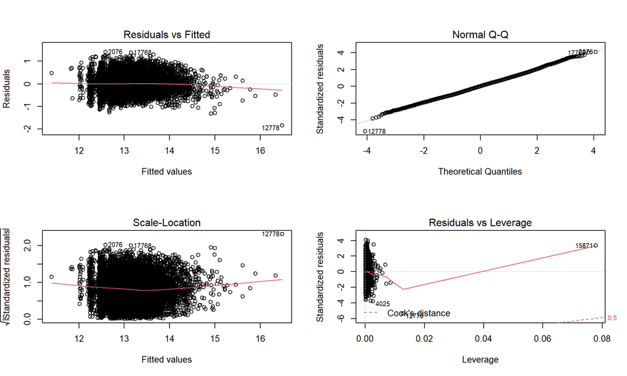

```r
par(mfrow=c(2,2))
plot(lm2)
```

```r
pearson.test(lm2$residuals)
```

```
##
##  Pearson chi-square normality test
##
## data:  lm2$residuals
## P = 232.03, p-value = 1.379e-11
```

```r
bptest(lm2)
```

```
##
##  studentized Breusch-Pagan test
##
## data:  lm2
## BP = 236.99, df = 5, p-value < 2.2e-16
```

Les résultats des tests de normalité et d’homoscédasticité sont identiques aux modèles précédents. Cependant, nous pouvons voir grâce aux graphiques que les données se rapprochent plus d’une distribution normale, car les points sont presque entièrement alignés sur la droite (voir graphique “Normal Q-Q”). La distribution est aussi plus aléatoire qu’avant car sur le graphique “Residuals vs Fitted” le nuage de points est plus étendu.

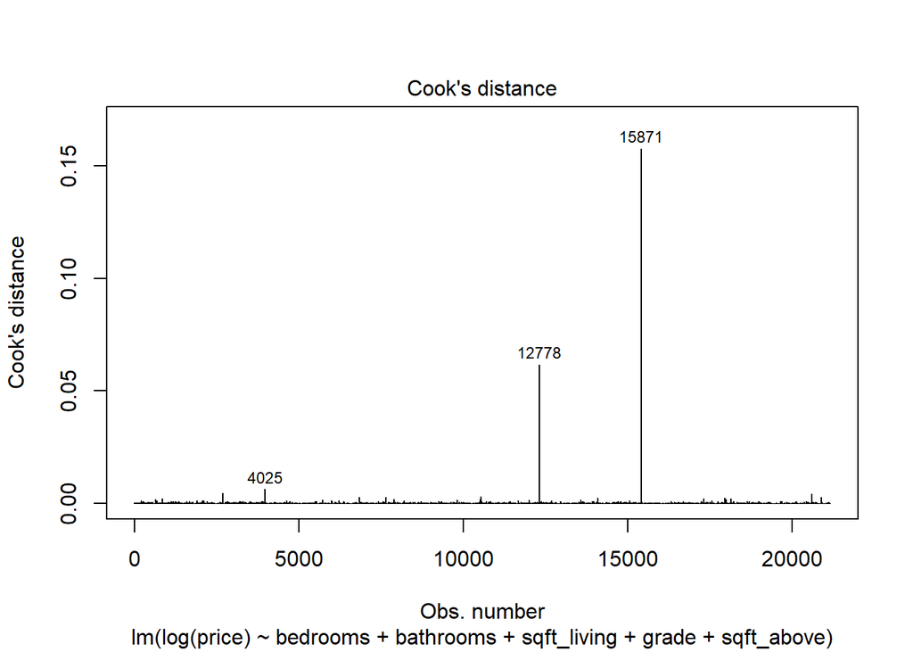

```r
plot(lm2, 4)
```

### *Conclusion*

Les résultats ne sont pas acceptés. Mais les conclusions sur les résidus sont meilleurs que pour les modèles 1,2 et 3.

# Test

Nous savons qu’il est possible de faire avec la méthode “Stepwise regression”.

```r
backward<- lm(log(price) ~ bedrooms + bathrooms + sqft_living + sqft_lot + floors + condition + grade + sqft_basement + yr_built + yr_renovated + zipcode + lat + long + sqft_living15 + sqft_lot15, data = na.omit(data))
step(backward, direction = "backward", trace=FALSE )
stp_b<- ols_step_both_p(backward, pent=0.01, prem=0.05, details=TRUE)
```

[output not shown]

# Conclusion

Il semble évident de dire que la plupart des variables de la base de données, telles que bedroomms, bathrooms, sqft_living ou encore sqft_above, ont un impact certain sur le prix de vente des maisons.

Cependant, aucun des modèles effectués ci-dessus ne permet de confirmer cette hypothèse à cause des résidus.

Mais, nous pouvons quand même dire que mettre le prix au logarithme et retirer les valeurs aberrantes permet d’obtenir un modèle plus performant et des résultats plus proches de la réalité.